# index

```python
import os
import numpy as np
import pandas as pd
import seaborn as sns
import matplotlib.pyplot as plt
%matplotlib inline

import tensorflow as tf
from tensorflow import keras
```

```python
# Verify GPU availability and clear the TensorFlow session
print("GPUs available: ", len(tf.config.experimental.list_physical_devices("GPU")))
tf.keras.backend.clear_session()
```

```
GPUs available:  1
```

## **Loading Data + Initial EDA**

```python
# Define the base directory
dataset_path = r'maize-leaf-dataset'

# our classes
classes = os.listdir(dataset_path)
print("Classes found:", classes)
```

[output not shown]

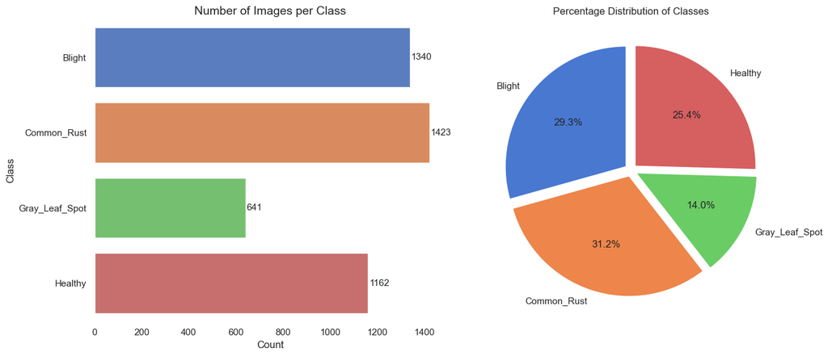

```python
# Count number of images per class
class_counts = {}
for cls in classes:
    cls_dir = os.path.join(dataset_path, cls)
    num_images = len(os.listdir(cls_dir))
    class_counts[cls] = num_images

# Convert to DataFrame
df = pd.DataFrame({
    'Class': list(class_counts.keys()),
    'Count': list(class_counts.values())
})

# Set the style
sns.set(style='white')

# Create the figure
plt.figure(figsize=(14, 6))

# 1. Horizontal Bar Plot
plt.subplot(1, 2, 1)
ax = sns.barplot(y='Class', x='Count', data=df, hue='Class', palette='muted', dodge=False, legend=False)

# Remove grid and spines
ax.grid(False)
sns.despine(left=True, bottom=True)

# Annotate counts on bars
for p in ax.patches:
    width = p.get_width()
    ax.annotate(f'{int(width)}',
                (width + 5, p.get_y() + p.get_height() / 2),
                ha='left', va='center', fontsize=11)

plt.title('Number of Images per Class', fontsize=14)
plt.xlabel('Count')
plt.ylabel('Class')

# 2. Pie Chart
plt.subplot(1, 2, 2)
plt.pie(df['Count'], labels=df['Class'], autopct='%1.1f%%',
        colors=sns.color_palette('muted'), startangle=90, explode=[0.05]*len(df))
plt.title('Percentage Distribution of Classes')

plt.tight_layout()
plt.show()
```

**Class Imbalance**  
There is a noticeable imbalance, especially for Gray Leaf Spot, which has significantly fewer samples than the others. This could cause the model to underperform on that class.

### Batching the Dataset

```python
BATCH_SIZE = 32
IMAGE_SIZE = 224
CHANNELS=3
```

```python
dataset = tf.keras.preprocessing.image_dataset_from_directory(
    dataset_path,
    seed=123,
    shuffle=True,
    image_size=(IMAGE_SIZE,IMAGE_SIZE),
    batch_size=BATCH_SIZE
)
```

```
Found 4566 files belonging to 4 classes.
```

```python
# gets the total number of batches in the dataset
len(dataset)
```

```
143
```

### Visualising Sample images

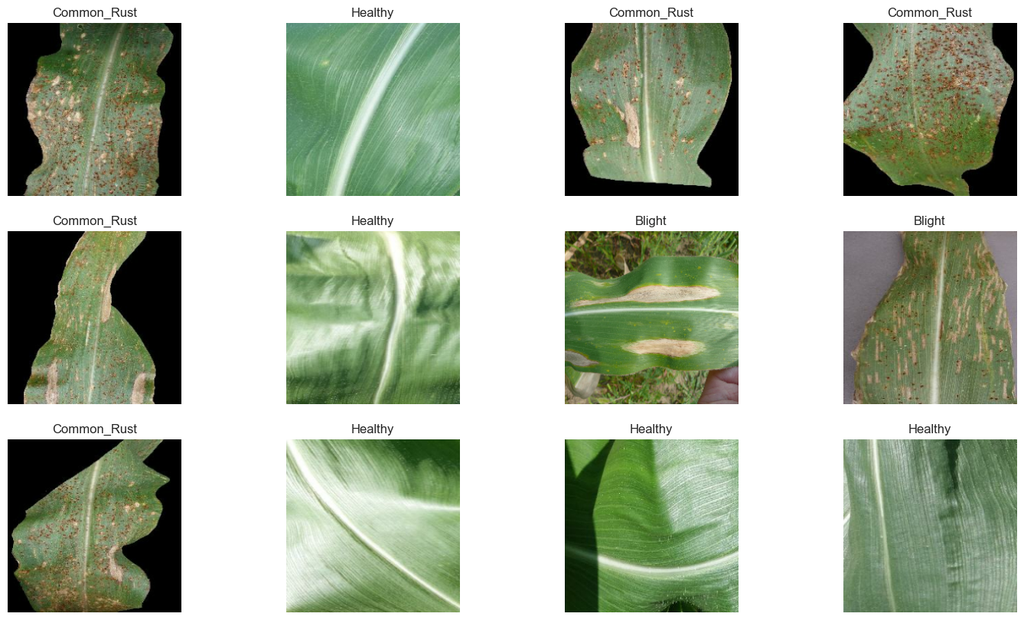

```python
# Displaying a grid of images from a batch
plt.figure(figsize=(18, 10))
for image_batch, labels_batch in dataset.take(1):
    for i in range(12):
        ax = plt.subplot(3, 4, i + 1)
        plt.imshow(image_batch[i].numpy().astype("uint8"))
        plt.title(classes[labels_batch[i]])
        plt.axis("off")
plt.show()
```

Visual Assesment:

1. **Common Rust** Appears as: Small, rusty-red or brown spots (like cinnamon powder).
2. **Blight** Appears as: Big, dark brown or black patches, like burnt leaves.
3. **Gray Leaf Spot** Appears as: Rectangular gray or tan spots with dark edges.
4. **Healthy** Appears as: Clean, green leaves with no spots or discoloration.

## **Setting up a validation framework**

```python
# split dataset into training, validation, and test sets.
def get_dataset_partitions_tf(ds, train_split=0.8, val_split=0.1, test_split=0.1, shuffle=True, shuffle_size=10000):

    #  Validate the splits
    assert (train_split + val_split + test_split) == 1, "Splits must sum to 1"

    # Get the dataset size
    ds_size = ds.cardinality().numpy()
    print(f"Total dataset size: {ds_size}")

    # Shuffles the dataset randomly
    if shuffle:
        shuffle_size = max(shuffle_size, ds_size)
        ds = ds.shuffle(shuffle_size, seed=123)

    # Calculate partition sizes
    train_size = int(train_split * ds_size)
    val_size = int(val_split * ds_size) + 1
    test_size = ds_size - train_size - val_size

     # Split the dataset
    train_ds = ds.take(train_size)
    val_ds = ds.skip(train_size).take(val_size)
    test_ds = ds.skip(train_size + val_size)

    return train_ds, val_ds, test_ds

# Split the dataset
train_ds, val_ds, test_ds = get_dataset_partitions_tf(dataset)

print(f"Training batches: {len(train_ds)}")   # Output the number of training batches
print(f"Validation batches: {len(val_ds)}")
print(f"Testing batches: {len(test_ds)}")
```

```
Total dataset size: 143
Training batches: 114
Validation batches: 15
Testing batches: 14
```

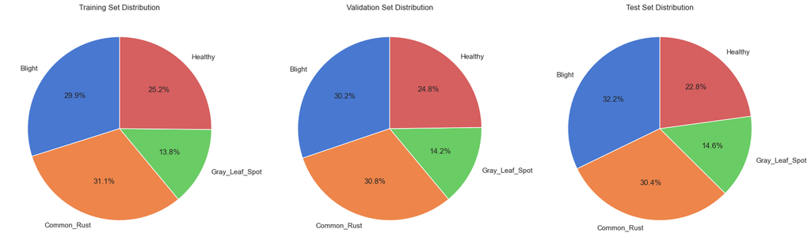

```python
def count_classes(dataset, class_names):
    class_counts = {name: 0 for name in class_names}
    for _, labels in dataset.as_numpy_iterator():
        for label in labels:
            class_counts[class_names[label]] += 1
    return class_counts

# Count class distributions
train_counts = count_classes(train_ds, classes)
val_counts = count_classes(val_ds, classes)
test_counts = count_classes(test_ds, classes)

data = {
    'Training Set': train_counts,
    'Validation Set': val_counts,
    'Test Set': test_counts
}

fig, axes = plt.subplots(1, 3, figsize=(18, 6))
muted_colors = sns.color_palette("muted", len(classes))

for ax, (partition, counts) in zip(axes, data.items()):
    labels = counts.keys()
    sizes = counts.values()
    ax.pie(
        sizes,
        labels=labels,
        autopct='%1.1f%%',
        startangle=90,
        colors=muted_colors
    )
    ax.set_title(f'{partition} Distribution')

plt.tight_layout()
plt.show()
```

Theres no class imbalance as the splits are proportional to the original datasets

## **Data Preprocessing**

```python
# resizing and normalizing pixel values
resize_and_rescale = tf.keras.Sequential([
  tf.keras.layers.Resizing(IMAGE_SIZE, IMAGE_SIZE),
  tf.keras.layers.Rescaling(1.0/255) # Normalizing the pixel values helps training converge faster and more accurately.
])

train_ds = train_ds.map(lambda x, y: (resize_and_rescale(x), y))
val_ds = val_ds.map(lambda x, y: (resize_and_rescale(x), y))
test_ds = test_ds.map(lambda x, y: (resize_and_rescale(x), y))
```

```python
# data augmentation

def augment(image, label):
    image = tf.image.random_flip_left_right(image)
    image = tf.image.random_flip_up_down(image)
    image = tf.image.rot90(image, tf.random.uniform(shape=[], minval=0, maxval=4, dtype=tf.int32))
    image = tf.image.random_brightness(image, max_delta=0.1)
    return image, label

train_ds = train_ds.map(augment)
```

```python
# Shape of our training batch
for img, label in train_ds.take(1):
    print("New shape:", img.shape)
```

```
New shape: (32, 224, 224, 3)
```

## **CNN Architectures**

```python
from tensorflow.keras.applications import EfficientNetB0
from tensorflow.keras.layers import GlobalAveragePooling2D, Dense, Dropout
```

### Training - MobileNetV2

```python
# Load MobileNet V2 as the base model
IMG_SHAPE = (IMAGE_SIZE, IMAGE_SIZE, CHANNELS)

base_model = tf.keras.applications.MobileNetV2(input_shape=IMG_SHAPE,
                                               include_top=False,
                                               weights='imagenet')
```

```python
# Freezing the Base
base_model.trainable = False
```

```python
# Adding our pooling layer
global_average_layer = tf.keras.layers.GlobalAveragePooling2D()
```

```python
# Adding the prediction Layer
prediction_layer = keras.layers.Dense(4, activation="softmax")
```

```python
# Now we will combine these layers together in a model.
model = tf.keras.Sequential([
  base_model,
  global_average_layer,
  prediction_layer
])
```

```python
model.summary()
```

[output not shown]

```python
learning_rate = 0.001

model.compile( optimizer = keras.optimizers.Adam(learning_rate=learning_rate),
              loss=tf.keras.losses.SparseCategoricalCrossentropy(from_logits=False),
              metrics=['accuracy'])
```

```python
# Now we can train it on our images
history = model.fit(train_ds,
                    epochs=10,
                    validation_data=val_ds)
```

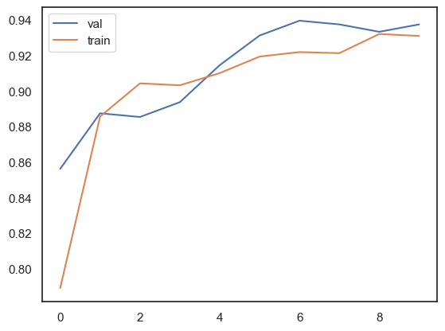

```python
hist = history.history
plt.plot(hist['val_accuracy'], label='val')
plt.plot(hist['accuracy'], label='train')

plt.legend()
```

```python
# Evaluate the model on the test dataset
scores = model.evaluate(test_ds)
print("Test accuracy:", scores[1])
```

```
Test accuracy: 0.928571343421936
```

### Training - Xception

```python
from tensorflow.keras.applications.xception import Xception


def make_model(learning_rate):


    IMG_SHAPE = (IMAGE_SIZE, IMAGE_SIZE, CHANNELS)

    base_model = Xception(
        weights='imagenet',
        include_top=False,
        input_shape=IMG_SHAPE
    )

    base_model.trainable = False

    #########################################

    vectors = tf.keras.layers.GlobalAveragePooling2D()


    outputs = keras.layers.Dense(4, activation="softmax")


    model = tf.keras.Sequential([
                                base_model,
                                vectors,
                                outputs
                                ])

    #########################################

    optimizer = keras.optimizers.Adam(learning_rate=learning_rate)
    loss=tf.keras.losses.SparseCategoricalCrossentropy(from_logits=False)

    model.compile(
        optimizer=optimizer,
        loss=loss,
        metrics=['accuracy']
    )

    return model
```

```python
learning_rate = 0.001

model = make_model(learning_rate=learning_rate)
history = model.fit(train_ds, epochs=10, validation_data=val_ds)
```

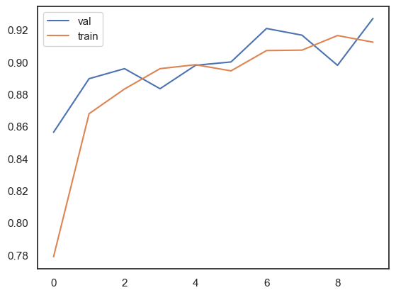

```python
hist = history.history
plt.plot(hist['val_accuracy'], label='val')
plt.plot(hist['accuracy'], label='train')

plt.legend()
```

```python
# Evaluate the model on the test dataset
scores = model.evaluate(test_ds)
print("Test accuracy:", scores[1])
```

```
Test accuracy: 0.9129464030265808
```

### Training - DenseNet121

```python
from tensorflow.keras.applications import DenseNet121


def make_model(learning_rate):


    IMG_SHAPE = (IMAGE_SIZE, IMAGE_SIZE, CHANNELS)

    base_model = DenseNet121(
        weights='imagenet',
        include_top=False,
        input_shape=IMG_SHAPE
    )

    base_model.trainable = False

    #########################################

    vectors = tf.keras.layers.GlobalAveragePooling2D()


    outputs = keras.layers.Dense(4, activation="softmax")


    model = tf.keras.Sequential([
                                base_model,
                                vectors,
                                outputs
                                ])

    #########################################

    optimizer = keras.optimizers.Adam(learning_rate=learning_rate)
    loss=tf.keras.losses.SparseCategoricalCrossentropy(from_logits=False)

    model.compile(
        optimizer=optimizer,
        loss=loss,
        metrics=['accuracy']
    )

    return model
```

```python
learning_rate = 0.001

model = make_model(learning_rate=learning_rate)
history = model.fit(train_ds, epochs=10, validation_data=val_ds)
```

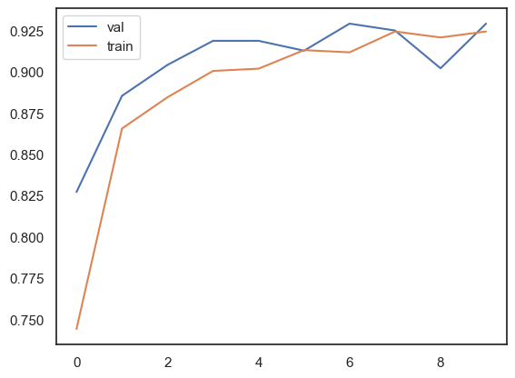

```python
hist = history.history
plt.plot(hist['val_accuracy'], label='val')
plt.plot(hist['accuracy'], label='train')

plt.legend()
```

```python
# Evaluate the model on the test dataset
scores = model.evaluate(test_ds)
print("Test accuracy:", scores[1])
```

```
Test accuracy: 0.9196428060531616
```

MobileNetV2 is the best performing model approximately 93% accuracy

## **Hyperparameter Tuning**

### Adjusting Learning Rate

```python
def make_model(learning_rate):

    IMG_SHAPE = (IMAGE_SIZE, IMAGE_SIZE, CHANNELS)


    base_model = tf.keras.applications.MobileNetV2(
        weights='imagenet',
        include_top=False,
        input_shape=IMG_SHAPE
    )
    base_model.trainable = False

    # input pipeline that connects base model to feature vector
    inputs = keras.Input(shape=IMG_SHAPE)
    base = base_model(inputs, training=False)
    vectors = keras.layers.GlobalAveragePooling2D()(base)


    # Output layer with softmax for 4 classes
    outputs = keras.layers.Dense(4, activation='softmax')(vectors)

    model = keras.Model(inputs, outputs)

    # Compile the model
    optimizer = keras.optimizers.Adam(learning_rate=learning_rate)
    loss = keras.losses.SparseCategoricalCrossentropy(from_logits=False)

    model.compile(
        optimizer=optimizer,
        loss=loss,
        metrics=['accuracy']
    )

    return model
```

```python
scores ={}
for lr in [0.0005, 0.001, 0.01]:
    print(lr)
    model = make_model(learning_rate=lr)
    history = model.fit(train_ds, epochs=10, validation_data=val_ds)
    scores[lr] = history.history

    print()
    print()
```

```
0.0005


0.001


0.01
```

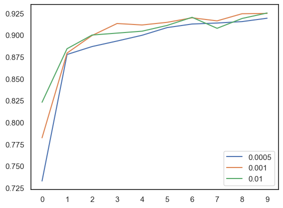

```python
# training accuracy for different learning rates
for lr, hist in scores.items():
    plt.plot(hist['accuracy'], label=lr)

plt.xticks(np.arange(10))
plt.legend()
```

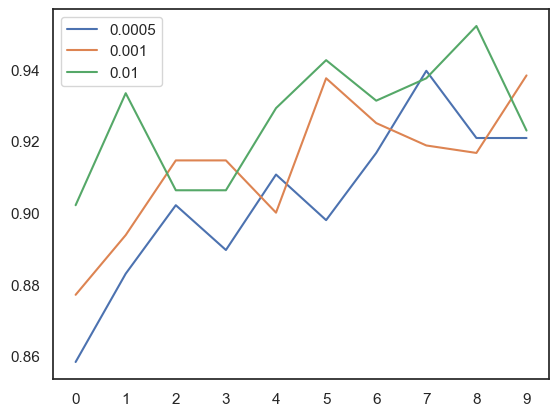

```python
for lr, hist in scores.items():
    plt.plot(hist['val_accuracy'], label=lr)

plt.xticks(np.arange(10))
plt.legend()
```

A moderate learning rate like 0.001 appears to balance training performance and validation generalization

### Adding more inner layers

```python
def make_model(learning_rate, size_inner):

    IMG_SHAPE = (IMAGE_SIZE, IMAGE_SIZE, CHANNELS)


    base_model = tf.keras.applications.MobileNetV2(
        weights='imagenet',
        include_top=False,
        input_shape=IMG_SHAPE
    )
    base_model.trainable = False

    # input pipeline that connects base model to feature vector
    inputs = keras.Input(shape=IMG_SHAPE)
    base = base_model(inputs, training=False)
    vectors = keras.layers.GlobalAveragePooling2D()(base)

    # Custom intermediate dense layer
    inner = keras.layers.Dense(size_inner, activation='relu')(vectors)

    # Output layer with softmax for 4 classes
    outputs = keras.layers.Dense(4, activation='softmax')(inner)

    model = keras.Model(inputs, outputs)

    # Compile the model
    optimizer = keras.optimizers.Adam(learning_rate=learning_rate)
    loss = keras.losses.SparseCategoricalCrossentropy(from_logits=False)

    model.compile(
        optimizer=optimizer,
        loss=loss,
        metrics=['accuracy']
    )

    return model
```

```python
learning_rate = 0.001

model = make_model(learning_rate=learning_rate, size_inner=100)
model.summary()
```

[output not shown]

```python
learning_rate = 0.001

scores = {}

for size in [10, 100, 500, 1000]:
    print(size)

    model = make_model(learning_rate=learning_rate, size_inner=size)
    history = model.fit(train_ds, epochs=10, validation_data=val_ds)
    scores[size] = history.history

    print()
    print()
```

```
10


100


500


1000
```

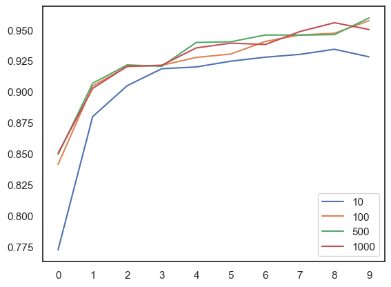

```python
# training accuracy for different learning rates
for lr, hist in scores.items():
    plt.plot(hist['accuracy'], label=lr)

plt.xticks(np.arange(10))
plt.legend()
```

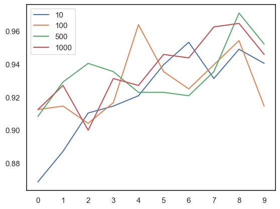

```python
for lr, hist in scores.items():
    plt.plot(hist['val_accuracy'], label=lr)

plt.xticks(np.arange(10))
plt.legend()
```

Models with 500 and 1000 units achieve high accuracy quickly and maintain it across epochs.

### Adding dropout

```python
def make_model(learning_rate, droprate):

    IMG_SHAPE = (IMAGE_SIZE, IMAGE_SIZE, CHANNELS)


    base_model = tf.keras.applications.MobileNetV2(
        weights='imagenet',
        include_top=False,
        input_shape=IMG_SHAPE
    )
    base_model.trainable = False

    # input pipeline that connects base model to feature vector
    inputs = keras.Input(shape=IMG_SHAPE)
    base = base_model(inputs, training=False)
    vectors = keras.layers.GlobalAveragePooling2D()(base)

    # Custom intermediate dense layer with dropout
    inner = keras.layers.Dense(256, activation='relu')(vectors)
    drop = keras.layers.Dropout(droprate)(inner)  # Regularizes the model to prevent overfitting

    # Output layer with softmax for 4 classes
    outputs = keras.layers.Dense(4, activation='softmax')(drop)

    model = keras.Model(inputs, outputs)

    # Compile the model
    optimizer = keras.optimizers.Adam(learning_rate=learning_rate)
    loss = keras.losses.SparseCategoricalCrossentropy(from_logits=False)

    model.compile(
        optimizer=optimizer,
        loss=loss,
        metrics=['accuracy']
    )

    return model
```

```python
learning_rate = 0.001

model = make_model(learning_rate=learning_rate, droprate=0.3)
model.summary()
```

[output not shown]

```python
scores = {}

for droprate in [0.0, 0.2, 0.5, 0.8]:
    print(droprate)

    model = make_model(
        learning_rate=learning_rate,
        droprate=droprate
    )

    history = model.fit(train_ds, epochs=20, validation_data=val_ds)
    scores[droprate] = history.history

    print()
    print()
```

```
0.0


0.2


0.5


0.8
```

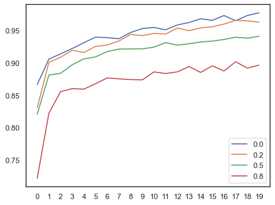

```python
# training accuracy for different learning rates
for lr, hist in scores.items():
    plt.plot(hist['accuracy'], label=lr)

plt.xticks(np.arange(20))
plt.legend()
```

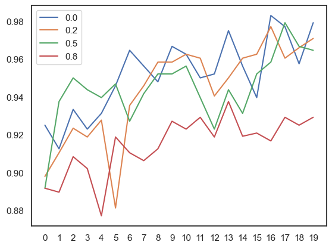

```python
for lr, hist in scores.items():
    plt.plot(hist['val_accuracy'], label=lr)

plt.xticks(np.arange(20))
plt.legend()
```

It seems that smaller drop rates improve our model